# Risk Factor Analysis

## Outcome Variable

**Outcome Variable:** whz

## Predictor Variables

**Intervention Variable:** mwtkg

**Adjustment Set:**

unadjusted

## Stratifying Variables

The analysis was stratified on these variable(s):

- agecat
- studyid
- country

## Data Summary

| agecat | studyid | country | mwtkg | n_cell | n |
| --- | --- | --- | --- | --- | --- |
| Birth | ki0047075b-MAL-ED | BANGLADESH | >=58 kg | 37 | 209 |
| Birth | ki0047075b-MAL-ED | BANGLADESH | <52 kg | 131 | 209 |
| Birth | ki0047075b-MAL-ED | BANGLADESH | [52-58) kg | 41 | 209 |
| Birth | ki0047075b-MAL-ED | BRAZIL | >=58 kg | 33 | 61 |
| Birth | ki0047075b-MAL-ED | BRAZIL | <52 kg | 14 | 61 |
| Birth | ki0047075b-MAL-ED | BRAZIL | [52-58) kg | 14 | 61 |
| Birth | ki0047075b-MAL-ED | INDIA | >=58 kg | 6 | 41 |
| Birth | ki0047075b-MAL-ED | INDIA | <52 kg | 28 | 41 |
| Birth | ki0047075b-MAL-ED | INDIA | [52-58) kg | 7 | 41 |
| Birth | ki0047075b-MAL-ED | NEPAL | >=58 kg | 9 | 26 |
| Birth | ki0047075b-MAL-ED | NEPAL | <52 kg | 7 | 26 |
| Birth | ki0047075b-MAL-ED | NEPAL | [52-58) kg | 10 | 26 |
| Birth | ki0047075b-MAL-ED | PERU | >=58 kg | 82 | 221 |
| Birth | ki0047075b-MAL-ED | PERU | <52 kg | 81 | 221 |
| Birth | ki0047075b-MAL-ED | PERU | [52-58) kg | 58 | 221 |
| Birth | ki0047075b-MAL-ED | SOUTH AFRICA | >=58 kg | 69 | 100 |
| Birth | ki0047075b-MAL-ED | SOUTH AFRICA | <52 kg | 10 | 100 |
| Birth | ki0047075b-MAL-ED | SOUTH AFRICA | [52-58) kg | 21 | 100 |
| Birth | ki0047075b-MAL-ED | TANZANIA, UNITED REPUBLIC OF | >=58 kg | 44 | 113 |
| Birth | ki0047075b-MAL-ED | TANZANIA, UNITED REPUBLIC OF | <52 kg | 40 | 113 |
| Birth | ki0047075b-MAL-ED | TANZANIA, UNITED REPUBLIC OF | [52-58) kg | 29 | 113 |
| Birth | ki1000304b-SAS-CompFeed | INDIA | >=58 kg | 89 | 1091 |
| Birth | ki1000304b-SAS-CompFeed | INDIA | <52 kg | 824 | 1091 |
| Birth | ki1000304b-SAS-CompFeed | INDIA | [52-58) kg | 178 | 1091 |
| Birth | ki1017093-NIH-Birth | BANGLADESH | >=58 kg | 79 | 575 |
| Birth | ki1017093-NIH-Birth | BANGLADESH | <52 kg | 414 | 575 |
| Birth | ki1017093-NIH-Birth | BANGLADESH | [52-58) kg | 82 | 575 |
| Birth | ki1017093b-PROVIDE | BANGLADESH | >=58 kg | 89 | 510 |
| Birth | ki1017093b-PROVIDE | BANGLADESH | <52 kg | 326 | 510 |
| Birth | ki1017093b-PROVIDE | BANGLADESH | [52-58) kg | 95 | 510 |

[output cut: 105 more lines]

The following strata were considered:

- agecat: 24 months, studyid: ki0047075b-MAL-ED, country: BANGLADESH
- agecat: 24 months, studyid: ki0047075b-MAL-ED, country: BRAZIL
- agecat: 24 months, studyid: ki0047075b-MAL-ED, country: INDIA
- agecat: 24 months, studyid: ki0047075b-MAL-ED, country: NEPAL
- agecat: 24 months, studyid: ki0047075b-MAL-ED, country: PERU
- agecat: 24 months, studyid: ki0047075b-MAL-ED, country: SOUTH AFRICA
- agecat: 24 months, studyid: ki0047075b-MAL-ED, country: TANZANIA, UNITED REPUBLIC OF
- agecat: 24 months, studyid: ki1017093-NIH-Birth, country: BANGLADESH
- agecat: 24 months, studyid: ki1017093b-PROVIDE, country: BANGLADESH
- agecat: 24 months, studyid: ki1017093c-NIH-Crypto, country: BANGLADESH
- agecat: 24 months, studyid: ki1066203-TanzaniaChild2, country: TANZANIA, UNITED REPUBLIC OF
- agecat: 24 months, studyid: ki1119695-PROBIT, country: BELARUS
- agecat: 24 months, studyid: ki1126311-ZVITAMBO, country: ZIMBABWE
- agecat: 24 months, studyid: ki1148112-LCNI-5, country: MALAWI
- agecat: 24 months, studyid: kiGH5241-JiVitA-3, country: BANGLADESH
- agecat: 6 months, studyid: ki0047075b-MAL-ED, country: BANGLADESH
- agecat: 6 months, studyid: ki0047075b-MAL-ED, country: BRAZIL
- agecat: 6 months, studyid: ki0047075b-MAL-ED, country: INDIA
- agecat: 6 months, studyid: ki0047075b-MAL-ED, country: NEPAL
- agecat: 6 months, studyid: ki0047075b-MAL-ED, country: PERU
- agecat: 6 months, studyid: ki0047075b-MAL-ED, country: SOUTH AFRICA
- agecat: 6 months, studyid: ki0047075b-MAL-ED, country: TANZANIA, UNITED REPUBLIC OF
- agecat: 6 months, studyid: ki1000304b-SAS-CompFeed, country: INDIA
- agecat: 6 months, studyid: ki1017093-NIH-Birth, country: BANGLADESH
- agecat: 6 months, studyid: ki1017093b-PROVIDE, country: BANGLADESH
- agecat: 6 months, studyid: ki1017093c-NIH-Crypto, country: BANGLADESH
- agecat: 6 months, studyid: ki1066203-TanzaniaChild2, country: TANZANIA, UNITED REPUBLIC OF
- agecat: 6 months, studyid: ki1119695-PROBIT, country: BELARUS
- agecat: 6 months, studyid: ki1126311-ZVITAMBO, country: ZIMBABWE
- agecat: 6 months, studyid: ki1148112-LCNI-5, country: MALAWI
- agecat: 6 months, studyid: kiGH5241-JiVitA-3, country: BANGLADESH
- agecat: Birth, studyid: ki0047075b-MAL-ED, country: BANGLADESH
- agecat: Birth, studyid: ki0047075b-MAL-ED, country: BRAZIL
- agecat: Birth, studyid: ki0047075b-MAL-ED, country: INDIA
- agecat: Birth, studyid: ki0047075b-MAL-ED, country: NEPAL
- agecat: Birth, studyid: ki0047075b-MAL-ED, country: PERU
- agecat: Birth, studyid: ki0047075b-MAL-ED, country: SOUTH AFRICA
- agecat: Birth, studyid: ki0047075b-MAL-ED, country: TANZANIA, UNITED REPUBLIC OF
- agecat: Birth, studyid: ki1000304b-SAS-CompFeed, country: INDIA
- agecat: Birth, studyid: ki1017093-NIH-Birth, country: BANGLADESH
- agecat: Birth, studyid: ki1017093b-PROVIDE, country: BANGLADESH
- agecat: Birth, studyid: ki1017093c-NIH-Crypto, country: BANGLADESH
- agecat: Birth, studyid: ki1119695-PROBIT, country: BELARUS
- agecat: Birth, studyid: ki1126311-ZVITAMBO, country: ZIMBABWE
- agecat: Birth, studyid: kiGH5241-JiVitA-3, country: BANGLADESH

### Dropped Strata

Some strata were dropped due to rare outcomes:

- agecat: 24 months, studyid: ki1066203-TanzaniaChild2, country: TANZANIA, UNITED REPUBLIC OF

## Methods Detail

We’re interested in the causal parameters $E[Y_a]$ for all values of $a \in \mathcal{A}$. These parameters represent the mean outcome if, possibly contrary to fact, we intervened to set all units to have $A=a$. Under the randomization and positivity assumptions, these are identified by the statistical parameters $\psi_a=E_W[E_{Y|A,W}(Y|A=a,W)]$. In addition, we’re interested in the mean of $Y$, $E[Y]$ under no intervention (the observed mean). We will estimate these parameters by using SuperLearner to fit the relevant likelihood factors – $E_{Y|A,W}(Y|A=a,W)$ and $p(A=a|W)$, and then updating our likelihood fit using a joint TMLE.

For unadjusted analyses ($W=\{\}$), initial likelihoods were estimated using Lrnr_glm to estimate the simple $E(Y|A)$ and Lrnr_mean to estimate $p(A)$. For adjusted analyses, a small library containing Lrnr_glmnet, Lrnr_xgboost, and Lrnr_mean was used.

Having estimated these parameters, we will then use the delta method to estimate relative risks and attributable risks relative to a prespecified baseline level of $A$.

# Results Detail

## Results Plots

[figure not shown]

[figure not shown]

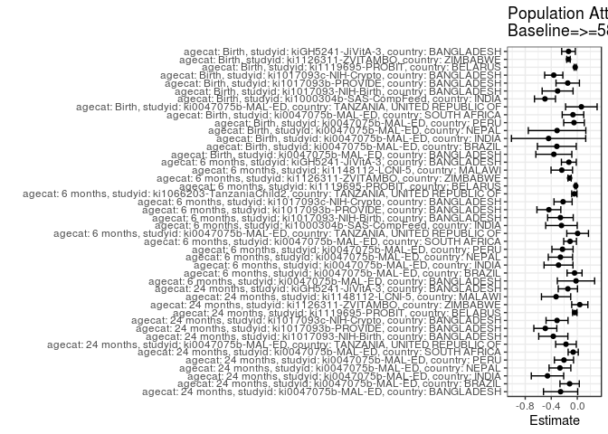

## Results Table

### Parameter: TSM

| agecat | studyid | country | intervention_level | baseline_level | estimate | ci_lower | ci_upper |
| --- | --- | --- | --- | --- | --- | --- | --- |
| Birth | ki0047075b-MAL-ED | BANGLADESH | >=58 kg | NA | -0.5929730 | -0.8859081 | -0.3000378 |
| Birth | ki0047075b-MAL-ED | BANGLADESH | <52 kg | NA | -1.0396947 | -1.2276410 | -0.8517483 |
| Birth | ki0047075b-MAL-ED | BANGLADESH | [52-58) kg | NA | -1.0026829 | -1.3235935 | -0.6817723 |
| Birth | ki0047075b-MAL-ED | BRAZIL | >=58 kg | NA | 0.7160606 | 0.3286633 | 1.1034579 |
| Birth | ki0047075b-MAL-ED | BRAZIL | <52 kg | NA | 0.1135714 | -0.6355404 | 0.8626833 |
| Birth | ki0047075b-MAL-ED | BRAZIL | [52-58) kg | NA | -0.0507143 | -0.6706476 | 0.5692190 |
| Birth | ki0047075b-MAL-ED | INDIA | >=58 kg | NA | -0.5266667 | -1.1151354 | 0.0618020 |
| Birth | ki0047075b-MAL-ED | INDIA | <52 kg | NA | -1.0517857 | -1.4197431 | -0.6838283 |
| Birth | ki0047075b-MAL-ED | INDIA | [52-58) kg | NA | -1.0100000 | -1.5034877 | -0.5165123 |
| Birth | ki0047075b-MAL-ED | NEPAL | >=58 kg | NA | -0.4577778 | -0.9265727 | 0.0110172 |
| Birth | ki0047075b-MAL-ED | NEPAL | <52 kg | NA | -0.8900000 | -1.4411585 | -0.3388415 |
| Birth | ki0047075b-MAL-ED | NEPAL | [52-58) kg | NA | -0.9630000 | -1.6574487 | -0.2685513 |
| Birth | ki0047075b-MAL-ED | PERU | >=58 kg | NA | 0.0074390 | -0.1889371 | 0.2038151 |
| Birth | ki0047075b-MAL-ED | PERU | <52 kg | NA | -0.2113580 | -0.4068464 | -0.0158697 |
| Birth | ki0047075b-MAL-ED | PERU | [52-58) kg | NA | 0.1208621 | -0.1298539 | 0.3715780 |
| Birth | ki0047075b-MAL-ED | SOUTH AFRICA | >=58 kg | NA | -0.1268116 | -0.3971704 | 0.1435472 |
| Birth | ki0047075b-MAL-ED | SOUTH AFRICA | <52 kg | NA | -0.6500000 | -1.3245997 | 0.0245997 |
| Birth | ki0047075b-MAL-ED | SOUTH AFRICA | [52-58) kg | NA | -0.1928571 | -0.7737761 | 0.3880618 |
| Birth | ki0047075b-MAL-ED | TANZANIA, UNITED REPUBLIC OF | >=58 kg | NA | 0.6956818 | 0.3908037 | 1.0005599 |
| Birth | ki0047075b-MAL-ED | TANZANIA, UNITED REPUBLIC OF | <52 kg | NA | 0.8267500 | 0.5064585 | 1.1470415 |
| Birth | ki0047075b-MAL-ED | TANZANIA, UNITED REPUBLIC OF | [52-58) kg | NA | 0.7589655 | 0.3532055 | 1.1647256 |
| Birth | ki1000304b-SAS-CompFeed | INDIA | >=58 kg | NA | -0.1695506 | -0.4411704 | 0.1020693 |
| Birth | ki1000304b-SAS-CompFeed | INDIA | <52 kg | NA | -0.7327427 | -0.8856002 | -0.5798853 |
| Birth | ki1000304b-SAS-CompFeed | INDIA | [52-58) kg | NA | -0.6057303 | -0.8530064 | -0.3584542 |
| Birth | ki1017093-NIH-Birth | BANGLADESH | >=58 kg | NA | -1.0473418 | -1.3031887 | -0.7914949 |
| Birth | ki1017093-NIH-Birth | BANGLADESH | <52 kg | NA | -1.4115338 | -1.5200783 | -1.3029893 |
| Birth | ki1017093-NIH-Birth | BANGLADESH | [52-58) kg | NA | -1.3303659 | -1.6012168 | -1.0595149 |
| Birth | ki1017093b-PROVIDE | BANGLADESH | >=58 kg | NA | -1.1591011 | -1.3598831 | -0.9583191 |
| Birth | ki1017093b-PROVIDE | BANGLADESH | <52 kg | NA | -1.3570859 | -1.4532953 | -1.2608765 |
| Birth | ki1017093b-PROVIDE | BANGLADESH | [52-58) kg | NA | -1.2688421 | -1.4441755 | -1.0935087 |

[output cut: 102 more lines]

### Parameter: E(Y)

| agecat | studyid | country | intervention_level | baseline_level | estimate | ci_lower | ci_upper |
| --- | --- | --- | --- | --- | --- | --- | --- |
| Birth | ki0047075b-MAL-ED | BANGLADESH | NA | NA | -0.9533493 | -1.0984355 | -0.8082631 |
| Birth | ki0047075b-MAL-ED | BRAZIL | NA | NA | 0.4018033 | 0.0834093 | 0.7201973 |
| Birth | ki0047075b-MAL-ED | INDIA | NA | NA | -0.9678049 | -1.2522118 | -0.6833979 |
| Birth | ki0047075b-MAL-ED | NEPAL | NA | NA | -0.7684615 | -1.1257770 | -0.4111460 |
| Birth | ki0047075b-MAL-ED | PERU | NA | NA | -0.0429864 | -0.1658406 | 0.0798678 |
| Birth | ki0047075b-MAL-ED | SOUTH AFRICA | NA | NA | -0.1930000 | -0.4278634 | 0.0418634 |
| Birth | ki0047075b-MAL-ED | TANZANIA, UNITED REPUBLIC OF | NA | NA | 0.7583186 | 0.5636385 | 0.9529987 |
| Birth | ki1000304b-SAS-CompFeed | INDIA | NA | NA | -0.6660770 | -0.8389738 | -0.4931801 |
| Birth | ki1017093-NIH-Birth | BANGLADESH | NA | NA | -1.3499217 | -1.4444634 | -1.2553801 |
| Birth | ki1017093b-PROVIDE | BANGLADESH | NA | NA | -1.3060980 | -1.3843247 | -1.2278714 |
| Birth | ki1017093c-NIH-Crypto | BANGLADESH | NA | NA | -1.2434730 | -1.3276901 | -1.1592559 |
| Birth | ki1119695-PROBIT | BELARUS | NA | NA | -1.1429853 | -1.3532634 | -0.9327073 |
| Birth | ki1126311-ZVITAMBO | ZIMBABWE | NA | NA | -0.4824198 | -0.5113303 | -0.4535093 |
| Birth | kiGH5241-JiVitA-3 | BANGLADESH | NA | NA | -0.7780622 | -0.7970926 | -0.7590319 |
| 6 months | ki0047075b-MAL-ED | BANGLADESH | NA | NA | -0.1376763 | -0.2664642 | -0.0088885 |
| 6 months | ki0047075b-MAL-ED | BRAZIL | NA | NA | 0.9648518 | 0.8004118 | 1.1292917 |
| 6 months | ki0047075b-MAL-ED | INDIA | NA | NA | -0.7034149 | -0.8300527 | -0.5767771 |
| 6 months | ki0047075b-MAL-ED | NEPAL | NA | NA | 0.1104308 | -0.0208643 | 0.2417259 |
| 6 months | ki0047075b-MAL-ED | PERU | NA | NA | 1.0548591 | 0.9328922 | 1.1768259 |
| 6 months | ki0047075b-MAL-ED | SOUTH AFRICA | NA | NA | 0.5291499 | 0.3751396 | 0.6831602 |
| 6 months | ki0047075b-MAL-ED | TANZANIA, UNITED REPUBLIC OF | NA | NA | 0.5362213 | 0.4049390 | 0.6675036 |
| 6 months | ki1000304b-SAS-CompFeed | INDIA | NA | NA | -0.6660835 | -0.8034722 | -0.5286949 |
| 6 months | ki1017093-NIH-Birth | BANGLADESH | NA | NA | -0.4474038 | -0.5378167 | -0.3569909 |
| 6 months | ki1017093b-PROVIDE | BANGLADESH | NA | NA | -0.1987071 | -0.2815473 | -0.1158669 |
| 6 months | ki1017093c-NIH-Crypto | BANGLADESH | NA | NA | 0.0297622 | -0.0491685 | 0.1086930 |
| 6 months | ki1066203-TanzaniaChild2 | TANZANIA, UNITED REPUBLIC OF | NA | NA | 0.0780261 | 0.0247830 | 0.1312691 |
| 6 months | ki1119695-PROBIT | BELARUS | NA | NA | 0.5834072 | 0.5254491 | 0.6413653 |
| 6 months | ki1126311-ZVITAMBO | ZIMBABWE | NA | NA | 0.2987004 | 0.2725093 | 0.3248915 |
| 6 months | ki1148112-LCNI-5 | MALAWI | NA | NA | 0.4518519 | 0.3806435 | 0.5230602 |
| 6 months | kiGH5241-JiVitA-3 | BANGLADESH | NA | NA | -0.5934435 | -0.6129939 | -0.5738931 |
| 24 months | ki0047075b-MAL-ED | BANGLADESH | NA | NA | -0.8192925 | -0.9412667 | -0.6973182 |
| 24 months | ki0047075b-MAL-ED | BRAZIL | NA | NA | 0.4443651 | 0.2404149 | 0.6483153 |
| 24 months | ki0047075b-MAL-ED | INDIA | NA | NA | -0.9519248 | -1.0678488 | -0.8360007 |
| 24 months | ki0047075b-MAL-ED | NEPAL | NA | NA | -0.3749123 | -0.4886073 | -0.2612173 |
| 24 months | ki0047075b-MAL-ED | PERU | NA | NA | 0.1111982 | -0.0118399 | 0.2342362 |
| 24 months | ki0047075b-MAL-ED | SOUTH AFRICA | NA | NA | 0.3916417 | 0.2704414 | 0.5128421 |
| 24 months | ki0047075b-MAL-ED | TANZANIA, UNITED REPUBLIC OF | NA | NA | 0.0547975 | -0.0703378 | 0.1799328 |
| 24 months | ki1017093-NIH-Birth | BANGLADESH | NA | NA | -0.9115790 | -1.0095022 | -0.8136559 |
| 24 months | ki1017093b-PROVIDE | BANGLADESH | NA | NA | -0.8914360 | -0.9741797 | -0.8086923 |
| 24 months | ki1017093c-NIH-Crypto | BANGLADESH | NA | NA | -0.6103502 | -0.7050157 | -0.5156847 |
| 24 months | ki1119695-PROBIT | BELARUS | NA | NA | 0.6888304 | 0.5749159 | 0.8027449 |
| 24 months | ki1126311-ZVITAMBO | ZIMBABWE | NA | NA | -1.1835154 | -1.2835950 | -1.0834359 |
| 24 months | ki1148112-LCNI-5 | MALAWI | NA | NA | -0.0466281 | -0.1286250 | 0.0353688 |
| 24 months | kiGH5241-JiVitA-3 | BANGLADESH | NA | NA | -1.2974564 | -1.3207535 | -1.2741592 |

### Parameter: ATE

| agecat | studyid | country | intervention_level | baseline_level | estimate | ci_lower | ci_upper |
| --- | --- | --- | --- | --- | --- | --- | --- |
| Birth | ki0047075b-MAL-ED | BANGLADESH | >=58 kg | >=58 kg | 0.0000000 | 0.0000000 | 0.0000000 |
| Birth | ki0047075b-MAL-ED | BANGLADESH | <52 kg | >=58 kg | -0.4467217 | -0.7947659 | -0.0986774 |
| Birth | ki0047075b-MAL-ED | BANGLADESH | [52-58) kg | >=58 kg | -0.4097100 | -0.8442150 | 0.0247950 |
| Birth | ki0047075b-MAL-ED | BRAZIL | >=58 kg | >=58 kg | 0.0000000 | 0.0000000 | 0.0000000 |
| Birth | ki0047075b-MAL-ED | BRAZIL | <52 kg | >=58 kg | -0.6024892 | -1.4458427 | 0.2408644 |
| Birth | ki0047075b-MAL-ED | BRAZIL | [52-58) kg | >=58 kg | -0.7667749 | -1.4977975 | -0.0357523 |
| Birth | ki0047075b-MAL-ED | INDIA | >=58 kg | >=58 kg | 0.0000000 | 0.0000000 | 0.0000000 |
| Birth | ki0047075b-MAL-ED | INDIA | <52 kg | >=58 kg | -0.5251190 | -1.2191566 | 0.1689185 |
| Birth | ki0047075b-MAL-ED | INDIA | [52-58) kg | >=58 kg | -0.4833333 | -1.2513343 | 0.2846676 |
| Birth | ki0047075b-MAL-ED | NEPAL | >=58 kg | >=58 kg | 0.0000000 | 0.0000000 | 0.0000000 |
| Birth | ki0047075b-MAL-ED | NEPAL | <52 kg | >=58 kg | -0.4322222 | -1.1557859 | 0.2913414 |
| Birth | ki0047075b-MAL-ED | NEPAL | [52-58) kg | >=58 kg | -0.5052222 | -1.3430932 | 0.3326487 |
| Birth | ki0047075b-MAL-ED | PERU | >=58 kg | >=58 kg | 0.0000000 | 0.0000000 | 0.0000000 |
| Birth | ki0047075b-MAL-ED | PERU | <52 kg | >=58 kg | -0.2187970 | -0.4958878 | 0.0582937 |
| Birth | ki0047075b-MAL-ED | PERU | [52-58) kg | >=58 kg | 0.1134230 | -0.2050453 | 0.4318913 |
| Birth | ki0047075b-MAL-ED | SOUTH AFRICA | >=58 kg | >=58 kg | 0.0000000 | 0.0000000 | 0.0000000 |
| Birth | ki0047075b-MAL-ED | SOUTH AFRICA | <52 kg | >=58 kg | -0.5231884 | -1.2499475 | 0.2035707 |
| Birth | ki0047075b-MAL-ED | SOUTH AFRICA | [52-58) kg | >=58 kg | -0.0660455 | -0.7067957 | 0.5747046 |
| Birth | ki0047075b-MAL-ED | TANZANIA, UNITED REPUBLIC OF | >=58 kg | >=58 kg | 0.0000000 | 0.0000000 | 0.0000000 |
| Birth | ki0047075b-MAL-ED | TANZANIA, UNITED REPUBLIC OF | <52 kg | >=58 kg | 0.1310682 | -0.3111278 | 0.5732642 |
| Birth | ki0047075b-MAL-ED | TANZANIA, UNITED REPUBLIC OF | [52-58) kg | >=58 kg | 0.0632837 | -0.4442514 | 0.5708188 |
| Birth | ki1000304b-SAS-CompFeed | INDIA | >=58 kg | >=58 kg | 0.0000000 | 0.0000000 | 0.0000000 |
| Birth | ki1000304b-SAS-CompFeed | INDIA | <52 kg | >=58 kg | -0.5631922 | -0.7576632 | -0.3687211 |
| Birth | ki1000304b-SAS-CompFeed | INDIA | [52-58) kg | >=58 kg | -0.4361798 | -0.5891414 | -0.2832181 |
| Birth | ki1017093-NIH-Birth | BANGLADESH | >=58 kg | >=58 kg | 0.0000000 | 0.0000000 | 0.0000000 |
| Birth | ki1017093-NIH-Birth | BANGLADESH | <52 kg | >=58 kg | -0.3641920 | -0.6421121 | -0.0862720 |
| Birth | ki1017093-NIH-Birth | BANGLADESH | [52-58) kg | >=58 kg | -0.2830241 | -0.6556067 | 0.0895586 |
| Birth | ki1017093b-PROVIDE | BANGLADESH | >=58 kg | >=58 kg | 0.0000000 | 0.0000000 | 0.0000000 |
| Birth | ki1017093b-PROVIDE | BANGLADESH | <52 kg | >=58 kg | -0.1979848 | -0.4206272 | 0.0246577 |
| Birth | ki1017093b-PROVIDE | BANGLADESH | [52-58) kg | >=58 kg | -0.1097410 | -0.3763028 | 0.1568208 |

[output cut: 102 more lines]

### Parameter: PAR

| agecat | studyid | country | intervention_level | baseline_level | estimate | ci_lower | ci_upper |
| --- | --- | --- | --- | --- | --- | --- | --- |
| Birth | ki0047075b-MAL-ED | BANGLADESH | >=58 kg | NA | -0.3603763 | -0.6369232 | -0.0838295 |
| Birth | ki0047075b-MAL-ED | BRAZIL | >=58 kg | NA | -0.3142573 | -0.6127089 | -0.0158057 |
| Birth | ki0047075b-MAL-ED | INDIA | >=58 kg | NA | -0.4411382 | -1.0119516 | 0.1296752 |
| Birth | ki0047075b-MAL-ED | NEPAL | >=58 kg | NA | -0.3106838 | -0.7526063 | 0.1312387 |
| Birth | ki0047075b-MAL-ED | PERU | >=58 kg | NA | -0.0504254 | -0.2086639 | 0.1078130 |
| Birth | ki0047075b-MAL-ED | SOUTH AFRICA | >=58 kg | NA | -0.0661884 | -0.2316730 | 0.0992962 |
| Birth | ki0047075b-MAL-ED | TANZANIA, UNITED REPUBLIC OF | >=58 kg | NA | 0.0626368 | -0.1791579 | 0.3044314 |
| Birth | ki1000304b-SAS-CompFeed | INDIA | >=58 kg | NA | -0.4965264 | -0.6579059 | -0.3351469 |
| Birth | ki1017093-NIH-Birth | BANGLADESH | >=58 kg | NA | -0.3025800 | -0.5400860 | -0.0650739 |
| Birth | ki1017093b-PROVIDE | BANGLADESH | >=58 kg | NA | -0.1469969 | -0.3268931 | 0.0328993 |
| Birth | ki1017093c-NIH-Crypto | BANGLADESH | >=58 kg | NA | -0.3616971 | -0.5014144 | -0.2219797 |
| Birth | ki1119695-PROBIT | BELARUS | >=58 kg | NA | -0.0323423 | -0.0480920 | -0.0165926 |
| Birth | ki1126311-ZVITAMBO | ZIMBABWE | >=58 kg | NA | -0.1356059 | -0.1627669 | -0.1084448 |
| Birth | kiGH5241-JiVitA-3 | BANGLADESH | >=58 kg | NA | -0.1347601 | -0.2396482 | -0.0298721 |
| 6 months | ki0047075b-MAL-ED | BANGLADESH | >=58 kg | NA | -0.0199590 | -0.3064303 | 0.2665124 |
| 6 months | ki0047075b-MAL-ED | BRAZIL | >=58 kg | NA | -0.0420096 | -0.1569930 | 0.0729739 |
| 6 months | ki0047075b-MAL-ED | INDIA | >=58 kg | NA | -0.2884982 | -0.5106574 | -0.0663391 |
| 6 months | ki0047075b-MAL-ED | NEPAL | >=58 kg | NA | -0.2590207 | -0.4457715 | -0.0722699 |
| 6 months | ki0047075b-MAL-ED | PERU | >=58 kg | NA | -0.2274659 | -0.3899690 | -0.0649629 |
| 6 months | ki0047075b-MAL-ED | SOUTH AFRICA | >=58 kg | NA | -0.1109711 | -0.2088400 | -0.0131022 |
| 6 months | ki0047075b-MAL-ED | TANZANIA, UNITED REPUBLIC OF | >=58 kg | NA | 0.0051575 | -0.1614841 | 0.1717991 |
| 6 months | ki1000304b-SAS-CompFeed | INDIA | >=58 kg | NA | -0.2434622 | -0.4856663 | -0.0012581 |
| 6 months | ki1017093-NIH-Birth | BANGLADESH | >=58 kg | NA | -0.2592465 | -0.4559222 | -0.0625708 |
| 6 months | ki1017093b-PROVIDE | BANGLADESH | >=58 kg | NA | -0.4365775 | -0.6202328 | -0.2529221 |
| 6 months | ki1017093c-NIH-Crypto | BANGLADESH | >=58 kg | NA | -0.2184986 | -0.3575761 | -0.0794211 |
| 6 months | ki1066203-TanzaniaChild2 | TANZANIA, UNITED REPUBLIC OF | >=58 kg | NA | -0.0456432 | -0.0863195 | -0.0049670 |
| 6 months | ki1119695-PROBIT | BELARUS | >=58 kg | NA | -0.0235754 | -0.0351992 | -0.0119515 |
| 6 months | ki1126311-ZVITAMBO | ZIMBABWE | >=58 kg | NA | -0.1182808 | -0.1432510 | -0.0933106 |
| 6 months | ki1148112-LCNI-5 | MALAWI | >=58 kg | NA | -0.2382359 | -0.4033191 | -0.0731526 |
| 6 months | kiGH5241-JiVitA-3 | BANGLADESH | >=58 kg | NA | -0.1296200 | -0.2439741 | -0.0152659 |
| 24 months | ki0047075b-MAL-ED | BANGLADESH | >=58 kg | NA | -0.2564175 | -0.5193738 | 0.0065389 |
| 24 months | ki0047075b-MAL-ED | BRAZIL | >=58 kg | NA | -0.1177603 | -0.2661794 | 0.0306588 |
| 24 months | ki0047075b-MAL-ED | INDIA | >=58 kg | NA | -0.4578458 | -0.7066438 | -0.2090479 |
| 24 months | ki0047075b-MAL-ED | NEPAL | >=58 kg | NA | -0.2663596 | -0.4335352 | -0.0991841 |
| 24 months | ki0047075b-MAL-ED | PERU | >=58 kg | NA | -0.2045594 | -0.3514777 | -0.0576411 |
| 24 months | ki0047075b-MAL-ED | SOUTH AFRICA | >=58 kg | NA | -0.0629069 | -0.1406025 | 0.0147887 |
| 24 months | ki0047075b-MAL-ED | TANZANIA, UNITED REPUBLIC OF | >=58 kg | NA | -0.1738001 | -0.3322456 | -0.0153545 |
| 24 months | ki1017093-NIH-Birth | BANGLADESH | >=58 kg | NA | -0.3687219 | -0.5924913 | -0.1449526 |
| 24 months | ki1017093b-PROVIDE | BANGLADESH | >=58 kg | NA | -0.4912128 | -0.6677409 | -0.3146846 |
| 24 months | ki1017093c-NIH-Crypto | BANGLADESH | >=58 kg | NA | -0.3112922 | -0.4800473 | -0.1425372 |
| 24 months | ki1119695-PROBIT | BELARUS | >=58 kg | NA | -0.0383293 | -0.0721718 | -0.0044868 |
| 24 months | ki1126311-ZVITAMBO | ZIMBABWE | >=58 kg | NA | 0.0383081 | -0.0858993 | 0.1625155 |
| 24 months | ki1148112-LCNI-5 | MALAWI | >=58 kg | NA | -0.3258062 | -0.5504736 | -0.1011388 |
| 24 months | kiGH5241-JiVitA-3 | BANGLADESH | >=58 kg | NA | -0.1449436 | -0.2930176 | 0.0031305 |